# Data621-Week05-Discussion

Pavan Akula

March 2, 2018

I will be using dataset from first project `Moneyball`, to demonstrate various `imputining` techniques for missing data. For the purpose of this discussion, I will using `knnImputation` function from `DMwR` package.

#### Load Data

```r
library(knitr)    # Report display, table format
library(kableExtra)
library(reshape2)
library(tidyverse)
library(DMwR)

BaseballDf <- read.csv("D:\\CUNY\\621\\Project01\\moneyball-training-data.csv", header= TRUE, stringsAsFactors = F)
BaseballDf$TEAM_BATTING_1B = BaseballDf$TEAM_BATTING_H - BaseballDf$TEAM_BATTING_2B - BaseballDf$TEAM_BATTING_3B - BaseballDf$TEAM_BATTING_HR

BaseballDf_o <- BaseballDf %>%
  select(TARGET_WINS, TEAM_BATTING_2B,TEAM_BATTING_3B,TEAM_BATTING_HR,TEAM_BATTING_BB,TEAM_BATTING_SO,TEAM_BASERUN_SB,TEAM_PITCHING_H,TEAM_PITCHING_SO,TEAM_FIELDING_E,TEAM_FIELDING_DP,TEAM_BATTING_1B)

BaseballDf_o[!complete.cases(BaseballDf_o),] %>%
  kable("html",caption = "Rows With Missing Values") %>%
  kable_styling(bootstrap_options = c("striped", "hover", "condensed", "responsive"), full_width = F, position = "left", font_size = 12) %>%
  scroll_box(width = "100%", height = "200px")
```

Rows With Missing Values

|  | TARGET_WINS | TEAM_BATTING_2B | TEAM_BATTING_3B | TEAM_BATTING_HR | TEAM_BATTING_BB | TEAM_BATTING_SO | TEAM_BASERUN_SB | TEAM_PITCHING_H | TEAM_PITCHING_SO | TEAM_FIELDING_E | TEAM_FIELDING_DP | TEAM_BATTING_1B |
| --- | --- | --- | --- | --- | --- | --- | --- | --- | --- | --- | --- | --- |
| 1 | 39 | 194 | 39 | 13 | 143 | 842 | NA | 9364 | 5456 | 1011 | NA | 1199 |
| 53 | 38 | 217 | 96 | 19 | 74 | 99 | NA | 4871 | 272 | 1252 | 88 | 1442 |
| 54 | 90 | 222 | 56 | 21 | 134 | 227 | NA | 3872 | 525 | 977 | 97 | 1374 |
| 55 | 113 | 246 | 100 | 11 | 176 | 327 | NA | 5103 | 883 | 780 | 97 | 1533 |
| 56 | 104 | 266 | 98 | 39 | 174 | 428 | NA | 3284 | 825 | 615 | 112 | 1300 |
| 57 | 77 | 258 | 79 | 39 | 203 | 426 | NA | 2897 | 822 | 710 | 104 | 1126 |
| 58 | 87 | 220 | 96 | 29 | 258 | 471 | NA | 3061 | 908 | 569 | 71 | 1242 |
| 59 | 104 | 345 | 142 | 56 | 203 | 699 | NA | 2761 | 1155 | 631 | NA | 1127 |
| 60 | 107 | 261 | 88 | 53 | 302 | 963 | NA | 2264 | 1405 | 546 | NA | 1149 |
| 61 | 67 | 208 | 77 | 32 | 275 | 755 | NA | 1914 | 1092 | 644 | NA | 1006 |
| 62 | 78 | 209 | 82 | 33 | 346 | 744 | 216 | 2080 | 1030 | 644 | NA | 1178 |
| 63 | 82 | 248 | 126 | 71 | 455 | 525 | 499 | 2249 | 703 | 699 | NA | 1235 |
| 64 | 85 | 202 | 108 | 68 | 341 | 633 | 354 | 1729 | 765 | 597 | NA | 1052 |
| 65 | 105 | 248 | 68 | 53 | 596 | 570 | 419 | 2003 | 721 | 523 | NA | 1214 |
| 66 | 93 | 213 | 76 | 38 | 646 | 627 | 347 | 1810 | 764 | 436 | NA | 1159 |
| 67 | 102 | 212 | 94 | 63 | 625 | 632 | 339 | 1742 | 742 | 420 | NA | 1115 |
| 68 | 108 | 224 | 63 | 82 | 705 | 367 | 305 | 2141 | 461 | 443 | NA | 1336 |
| 69 | 102 | 334 | 115 | 126 | 657 | 320 | 296 | 2498 | 393 | 509 | NA | 1460 |
| 70 | 88 | 244 | 70 | 67 | 618 | 292 | 246 | 2094 | 361 | 450 | NA | 1312 |
| 71 | 92 | 216 | 92 | 45 | 512 | 339 | 298 | 2165 | 419 | 455 | NA | 1398 |
| 72 | 114 | 282 | 102 | 55 | 519 | 322 | 286 | 2371 | 395 | 334 | NA | 1493 |
| 73 | 111 | 207 | 60 | 58 | 440 | 329 | 187 | 1810 | 358 | 325 | NA | 1340 |
| 74 | 101 | 190 | 96 | 42 | 459 | 287 | 197 | 1723 | 306 | 314 | NA | 1289 |
| 77 | 68 | 207 | 55 | 29 | 467 | NA | 187 | 1578 | NA | 412 | 104 | 1053 |
| 78 | 58 | 162 | 53 | 25 | 335 | NA | 151 | 1365 | NA | 358 | 96 | 1049 |
| 79 | 54 | 156 | 55 | 18 | 318 | NA | 139 | 1346 | NA | 327 | 94 | 1051 |
| 80 | 53 | 146 | 46 | 17 | 382 | NA | 100 | 1283 | NA | 362 | 109 | 987 |
| 81 | 63 | 155 | 67 | 24 | 452 | NA | 129 | 1465 | NA | 273 | 140 | 1092 |
| 82 | 66 | 144 | 45 | 18 | 436 | NA | 141 | 1359 | NA | 265 | 95 | 1085 |
| 83 | 48 | 131 | 46 | 16 | 424 | NA | 143 | 1257 | NA | 360 | 107 | 994 |

[output cut: 411 more lines]

```r
apply(BaseballDf_o, 2, function(x) sum(is.na(x))) %>%
  melt() %>%
  rownames_to_column() %>%
  kable("html", caption = "Missing Value Count", col.names = c("Variable", "Count")) %>%
    kable_styling(bootstrap_options = c("striped", "hover", "condensed", "responsive"), full_width = F, position = "left", font_size = 12)
```

Missing Value Count

| Variable | Count |
| --- | --- |
| TARGET_WINS | 0 |
| TEAM_BATTING_2B | 0 |
| TEAM_BATTING_3B | 0 |
| TEAM_BATTING_HR | 0 |
| TEAM_BATTING_BB | 0 |
| TEAM_BATTING_SO | 102 |
| TEAM_BASERUN_SB | 131 |
| TEAM_PITCHING_H | 0 |
| TEAM_PITCHING_SO | 102 |
| TEAM_FIELDING_E | 0 |
| TEAM_FIELDING_DP | 286 |
| TEAM_BATTING_1B | 0 |

Above table displays columns missing data. I will working with `TEAM_BATTING_SO`.

#### Imputation With Mean

Lets work with one variable `TEAM_BATTING_SO`.

- Remove all the missing value rows from the dataset and create training dataset
- Update 40 with `NA` values.
- Update `NA` values with `Mean`
- Run accuracy test using `regr.eval` function from `DMwR` package.

```r
options(scipen=10, digits=10)

set.seed(100)
BaseballDf_NA <- BaseballDf_o[complete.cases(BaseballDf_o),]
BaseballDf_NA[sample(1:nrow(BaseballDf_NA), 40), "TEAM_BATTING_SO"] <- NA

missing.row <- BaseballDf_NA[!complete.cases(BaseballDf_NA),]

BaseballDf_NA[!complete.cases(BaseballDf_NA),] %>%
  kable("html",caption = "Manually Updated NA Rows") %>%
  kable_styling(bootstrap_options = c("striped", "hover", "condensed", "responsive"), full_width = F, position = "left", font_size = 12) %>%
  scroll_box(width = "100%", height = "200px")
```

Manually Updated NA Rows

|  | TARGET_WINS | TEAM_BATTING_2B | TEAM_BATTING_3B | TEAM_BATTING_HR | TEAM_BATTING_BB | TEAM_BATTING_SO | TEAM_BASERUN_SB | TEAM_PITCHING_H | TEAM_PITCHING_SO | TEAM_FIELDING_E | TEAM_FIELDING_DP | TEAM_BATTING_1B |
| --- | --- | --- | --- | --- | --- | --- | --- | --- | --- | --- | --- | --- |
| 134 | 85 | 220 | 32 | 207 | 512 | NA | 59 | 1476 | 913 | 154 | 139 | 1017 |
| 292 | 88 | 234 | 70 | 34 | 512 | NA | 160 | 1520 | 652 | 272 | 110 | 1107 |
| 383 | 94 | 334 | 42 | 176 | 597 | NA | 67 | 1551 | 928 | 127 | 131 | 999 |
| 450 | 97 | 229 | 106 | 57 | 615 | NA | 225 | 1477 | 683 | 274 | 120 | 1012 |
| 498 | 72 | 202 | 33 | 134 | 532 | NA | 65 | 1316 | 948 | 171 | 166 | 947 |
| 605 | 92 | 179 | 29 | 114 | 538 | NA | 105 | 1337 | 1096 | 142 | 143 | 949 |
| 634 | 81 | 289 | 29 | 217 | 555 | NA | 75 | 1475 | 952 | 97 | 157 | 940 |
| 667 | 82 | 206 | 105 | 27 | 328 | NA | 161 | 1533 | 528 | 260 | 126 | 1119 |
| 720 | 88 | 269 | 42 | 181 | 600 | NA | 170 | 1513 | 911 | 95 | 154 | 1021 |
| 791 | 101 | 253 | 56 | 162 | 675 | NA | 56 | 1675 | 628 | 119 | 191 | 1132 |
| 812 | 75 | 194 | 19 | 95 | 436 | NA | 51 | 1316 | 821 | 115 | 163 | 959 |
| 816 | 83 | 193 | 39 | 87 | 488 | NA | 76 | 1477 | 655 | 123 | 162 | 1131 |
| 839 | 74 | 255 | 26 | 192 | 542 | NA | 52 | 1349 | 1000 | 113 | 161 | 876 |
| 919 | 89 | 246 | 44 | 108 | 802 | NA | 55 | 1508 | 625 | 163 | 149 | 1036 |
| 953 | 92 | 283 | 53 | 156 | 508 | NA | 93 | 1530 | 831 | 124 | 142 | 1038 |
| 1068 | 92 | 227 | 41 | 101 | 554 | NA | 154 | 1428 | 897 | 111 | 139 | 1059 |
| 1112 | 73 | 156 | 80 | 13 | 273 | NA | 145 | 1740 | 539 | 248 | 95 | 1104 |
| 1116 | 80 | 225 | 85 | 65 | 447 | NA | 75 | 1725 | 423 | 306 | 144 | 1265 |
| 1224 | 95 | 277 | 41 | 216 | 484 | NA | 84 | 1599 | 714 | 125 | 185 | 1065 |
| 1228 | 91 | 272 | 46 | 163 | 598 | NA | 176 | 1552 | 1040 | 145 | 155 | 1071 |
| 1244 | 81 | 327 | 19 | 175 | 531 | NA | 79 | 1413 | 1162 | 119 | 139 | 892 |
| 1257 | 85 | 185 | 85 | 19 | 494 | NA | 231 | 1378 | 708 | 265 | 122 | 1021 |
| 1271 | 79 | 291 | 98 | 42 | 506 | NA | 116 | 1670 | 431 | 189 | 154 | 1157 |
| 1412 | 75 | 182 | 55 | 29 | 525 | NA | 144 | 1374 | 599 | 238 | 137 | 1032 |
| 1421 | 96 | 276 | 79 | 127 | 675 | NA | 83 | 1668 | 642 | 220 | 123 | 1104 |
| 1505 | 38 | 179 | 69 | 20 | 430 | NA | 160 | 1358 | 707 | 330 | 133 | 1015 |
| 1540 | 62 | 206 | 42 | 176 | 385 | NA | 37 | 1415 | 852 | 132 | 172 | 912 |
| 1541 | 77 | 206 | 53 | 145 | 475 | NA | 23 | 1435 | 827 | 131 | 175 | 960 |
| 1577 | 87 | 287 | 20 | 235 | 770 | NA | 70 | 1430 | 1129 | 122 | 162 | 888 |
| 1673 | 101 | 266 | 56 | 186 | 573 | NA | 135 | 1548 | 806 | 120 | 168 | 1040 |
| 1728 | 73 | 156 | 83 | 19 | 438 | NA | 155 | 1324 | 673 | 235 | 101 | 1001 |
| 1733 | 83 | 152 | 96 | 20 | 401 | NA | 228 | 1537 | 517 | 186 | 104 | 1051 |
| 1846 | 83 | 241 | 28 | 109 | 513 | NA | 60 | 1405 | 809 | 124 | 158 | 1027 |
| 1977 | 86 | 257 | 35 | 165 | 729 | NA | 83 | 1460 | 1005 | 170 | 153 | 1003 |
| 1984 | 89 | 240 | 41 | 117 | 554 | NA | 87 | 1331 | 814 | 146 | 118 | 933 |
| 1992 | 83 | 227 | 44 | 113 | 550 | NA | 121 | 1353 | 1023 | 129 | 145 | 969 |
| 2087 | 92 | 247 | 45 | 139 | 519 | NA | 61 | 1657 | 744 | 138 | 177 | 1144 |
| 2131 | 97 | 285 | 26 | 175 | 542 | NA | 86 | 1475 | 927 | 103 | 168 | 989 |
| 2195 | 57 | 209 | 35 | 93 | 434 | NA | 101 | 1861 | 1299 | 160 | 156 | 881 |
| 2266 | 88 | 297 | 27 | 148 | 492 | NA | 108 | 1441 | 1077 | 126 | 121 | 969 |

```r
BaseballDf_NA$TEAM_BATTING_SO[is.na(BaseballDf_NA$TEAM_BATTING_SO)] <- mean(BaseballDf_NA$TEAM_BATTING_SO, na.rm = T)

BaseballDf_NA[rownames(missing.row),] %>%
  kable("html",caption = "Manually Updated NA Rows - Mean") %>%
  kable_styling(bootstrap_options = c("striped", "hover", "condensed", "responsive"), full_width = F, position = "left", font_size = 12) %>%
  scroll_box(width = "100%", height = "200px")
```

Manually Updated NA Rows - Mean

|  | TARGET_WINS | TEAM_BATTING_2B | TEAM_BATTING_3B | TEAM_BATTING_HR | TEAM_BATTING_BB | TEAM_BATTING_SO | TEAM_BASERUN_SB | TEAM_PITCHING_H | TEAM_PITCHING_SO | TEAM_FIELDING_E | TEAM_FIELDING_DP | TEAM_BATTING_1B |
| --- | --- | --- | --- | --- | --- | --- | --- | --- | --- | --- | --- | --- |
| 134 | 85 | 220 | 32 | 207 | 512 | 786.8523677 | 59 | 1476 | 913 | 154 | 139 | 1017 |
| 292 | 88 | 234 | 70 | 34 | 512 | 786.8523677 | 160 | 1520 | 652 | 272 | 110 | 1107 |
| 383 | 94 | 334 | 42 | 176 | 597 | 786.8523677 | 67 | 1551 | 928 | 127 | 131 | 999 |
| 450 | 97 | 229 | 106 | 57 | 615 | 786.8523677 | 225 | 1477 | 683 | 274 | 120 | 1012 |
| 498 | 72 | 202 | 33 | 134 | 532 | 786.8523677 | 65 | 1316 | 948 | 171 | 166 | 947 |
| 605 | 92 | 179 | 29 | 114 | 538 | 786.8523677 | 105 | 1337 | 1096 | 142 | 143 | 949 |
| 634 | 81 | 289 | 29 | 217 | 555 | 786.8523677 | 75 | 1475 | 952 | 97 | 157 | 940 |
| 667 | 82 | 206 | 105 | 27 | 328 | 786.8523677 | 161 | 1533 | 528 | 260 | 126 | 1119 |
| 720 | 88 | 269 | 42 | 181 | 600 | 786.8523677 | 170 | 1513 | 911 | 95 | 154 | 1021 |
| 791 | 101 | 253 | 56 | 162 | 675 | 786.8523677 | 56 | 1675 | 628 | 119 | 191 | 1132 |
| 812 | 75 | 194 | 19 | 95 | 436 | 786.8523677 | 51 | 1316 | 821 | 115 | 163 | 959 |
| 816 | 83 | 193 | 39 | 87 | 488 | 786.8523677 | 76 | 1477 | 655 | 123 | 162 | 1131 |
| 839 | 74 | 255 | 26 | 192 | 542 | 786.8523677 | 52 | 1349 | 1000 | 113 | 161 | 876 |
| 919 | 89 | 246 | 44 | 108 | 802 | 786.8523677 | 55 | 1508 | 625 | 163 | 149 | 1036 |
| 953 | 92 | 283 | 53 | 156 | 508 | 786.8523677 | 93 | 1530 | 831 | 124 | 142 | 1038 |
| 1068 | 92 | 227 | 41 | 101 | 554 | 786.8523677 | 154 | 1428 | 897 | 111 | 139 | 1059 |
| 1112 | 73 | 156 | 80 | 13 | 273 | 786.8523677 | 145 | 1740 | 539 | 248 | 95 | 1104 |
| 1116 | 80 | 225 | 85 | 65 | 447 | 786.8523677 | 75 | 1725 | 423 | 306 | 144 | 1265 |
| 1224 | 95 | 277 | 41 | 216 | 484 | 786.8523677 | 84 | 1599 | 714 | 125 | 185 | 1065 |
| 1228 | 91 | 272 | 46 | 163 | 598 | 786.8523677 | 176 | 1552 | 1040 | 145 | 155 | 1071 |
| 1244 | 81 | 327 | 19 | 175 | 531 | 786.8523677 | 79 | 1413 | 1162 | 119 | 139 | 892 |
| 1257 | 85 | 185 | 85 | 19 | 494 | 786.8523677 | 231 | 1378 | 708 | 265 | 122 | 1021 |
| 1271 | 79 | 291 | 98 | 42 | 506 | 786.8523677 | 116 | 1670 | 431 | 189 | 154 | 1157 |
| 1412 | 75 | 182 | 55 | 29 | 525 | 786.8523677 | 144 | 1374 | 599 | 238 | 137 | 1032 |
| 1421 | 96 | 276 | 79 | 127 | 675 | 786.8523677 | 83 | 1668 | 642 | 220 | 123 | 1104 |
| 1505 | 38 | 179 | 69 | 20 | 430 | 786.8523677 | 160 | 1358 | 707 | 330 | 133 | 1015 |
| 1540 | 62 | 206 | 42 | 176 | 385 | 786.8523677 | 37 | 1415 | 852 | 132 | 172 | 912 |
| 1541 | 77 | 206 | 53 | 145 | 475 | 786.8523677 | 23 | 1435 | 827 | 131 | 175 | 960 |
| 1577 | 87 | 287 | 20 | 235 | 770 | 786.8523677 | 70 | 1430 | 1129 | 122 | 162 | 888 |
| 1673 | 101 | 266 | 56 | 186 | 573 | 786.8523677 | 135 | 1548 | 806 | 120 | 168 | 1040 |
| 1728 | 73 | 156 | 83 | 19 | 438 | 786.8523677 | 155 | 1324 | 673 | 235 | 101 | 1001 |
| 1733 | 83 | 152 | 96 | 20 | 401 | 786.8523677 | 228 | 1537 | 517 | 186 | 104 | 1051 |
| 1846 | 83 | 241 | 28 | 109 | 513 | 786.8523677 | 60 | 1405 | 809 | 124 | 158 | 1027 |
| 1977 | 86 | 257 | 35 | 165 | 729 | 786.8523677 | 83 | 1460 | 1005 | 170 | 153 | 1003 |
| 1984 | 89 | 240 | 41 | 117 | 554 | 786.8523677 | 87 | 1331 | 814 | 146 | 118 | 933 |
| 1992 | 83 | 227 | 44 | 113 | 550 | 786.8523677 | 121 | 1353 | 1023 | 129 | 145 | 969 |
| 2087 | 92 | 247 | 45 | 139 | 519 | 786.8523677 | 61 | 1657 | 744 | 138 | 177 | 1144 |
| 2131 | 97 | 285 | 26 | 175 | 542 | 786.8523677 | 86 | 1475 | 927 | 103 | 168 | 989 |
| 2195 | 57 | 209 | 35 | 93 | 434 | 786.8523677 | 101 | 1861 | 1299 | 160 | 156 | 881 |
| 2266 | 88 | 297 | 27 | 148 | 492 | 786.8523677 | 108 | 1441 | 1077 | 126 | 121 | 969 |

```r
actuals <- BaseballDf_o[rownames(missing.row),]$TEAM_BATTING_SO
predicteds <- BaseballDf_NA[rownames(missing.row),]$TEAM_BATTING_SO
regr.eval(actuals, predicteds)
```

```
##              mae              mse             rmse             mape
##   171.6147632312 41697.3021574165   204.1991727638     0.2558558889
```

```r
Accuracy <- data.frame(regr.eval(actuals, predicteds), stringsAsFactors = F) %>%
  rbind('Impute' = "Mean") %>%
  t()
```

Results of `mae`, `mse` and `rmse` are very high. Ideal values should be close to `zero`.

#### Imputation With Median

- Copy original dataset
- Remove all the missing value rows from the dataset and create a training dataset
- Update 40 with `NA` values.
- Update `NA` values with `Median`
- Run accuracy test using `regr.eval` function from `DMwR` package.

```r
options(scipen=10, digits=10)

BaseballDf_NA[rownames(missing.row),]$TEAM_BATTING_SO <- NA
BaseballDf_NA$TEAM_BATTING_SO[is.na(BaseballDf_NA$TEAM_BATTING_SO)] <- median(BaseballDf_NA$TEAM_BATTING_SO, na.rm = T)

BaseballDf_NA[rownames(missing.row),] %>%
  kable("html",caption = "Manually Updated NA Rows - Median") %>%
  kable_styling(bootstrap_options = c("striped", "hover", "condensed", "responsive"), full_width = F, position = "left", font_size = 12) %>%
  scroll_box(width = "100%", height = "200px")
```

Manually Updated NA Rows - Median

|  | TARGET_WINS | TEAM_BATTING_2B | TEAM_BATTING_3B | TEAM_BATTING_HR | TEAM_BATTING_BB | TEAM_BATTING_SO | TEAM_BASERUN_SB | TEAM_PITCHING_H | TEAM_PITCHING_SO | TEAM_FIELDING_E | TEAM_FIELDING_DP | TEAM_BATTING_1B |
| --- | --- | --- | --- | --- | --- | --- | --- | --- | --- | --- | --- | --- |
| 134 | 85 | 220 | 32 | 207 | 512 | 816 | 59 | 1476 | 913 | 154 | 139 | 1017 |
| 292 | 88 | 234 | 70 | 34 | 512 | 816 | 160 | 1520 | 652 | 272 | 110 | 1107 |
| 383 | 94 | 334 | 42 | 176 | 597 | 816 | 67 | 1551 | 928 | 127 | 131 | 999 |
| 450 | 97 | 229 | 106 | 57 | 615 | 816 | 225 | 1477 | 683 | 274 | 120 | 1012 |
| 498 | 72 | 202 | 33 | 134 | 532 | 816 | 65 | 1316 | 948 | 171 | 166 | 947 |
| 605 | 92 | 179 | 29 | 114 | 538 | 816 | 105 | 1337 | 1096 | 142 | 143 | 949 |
| 634 | 81 | 289 | 29 | 217 | 555 | 816 | 75 | 1475 | 952 | 97 | 157 | 940 |
| 667 | 82 | 206 | 105 | 27 | 328 | 816 | 161 | 1533 | 528 | 260 | 126 | 1119 |
| 720 | 88 | 269 | 42 | 181 | 600 | 816 | 170 | 1513 | 911 | 95 | 154 | 1021 |
| 791 | 101 | 253 | 56 | 162 | 675 | 816 | 56 | 1675 | 628 | 119 | 191 | 1132 |
| 812 | 75 | 194 | 19 | 95 | 436 | 816 | 51 | 1316 | 821 | 115 | 163 | 959 |
| 816 | 83 | 193 | 39 | 87 | 488 | 816 | 76 | 1477 | 655 | 123 | 162 | 1131 |
| 839 | 74 | 255 | 26 | 192 | 542 | 816 | 52 | 1349 | 1000 | 113 | 161 | 876 |
| 919 | 89 | 246 | 44 | 108 | 802 | 816 | 55 | 1508 | 625 | 163 | 149 | 1036 |
| 953 | 92 | 283 | 53 | 156 | 508 | 816 | 93 | 1530 | 831 | 124 | 142 | 1038 |
| 1068 | 92 | 227 | 41 | 101 | 554 | 816 | 154 | 1428 | 897 | 111 | 139 | 1059 |
| 1112 | 73 | 156 | 80 | 13 | 273 | 816 | 145 | 1740 | 539 | 248 | 95 | 1104 |
| 1116 | 80 | 225 | 85 | 65 | 447 | 816 | 75 | 1725 | 423 | 306 | 144 | 1265 |
| 1224 | 95 | 277 | 41 | 216 | 484 | 816 | 84 | 1599 | 714 | 125 | 185 | 1065 |
| 1228 | 91 | 272 | 46 | 163 | 598 | 816 | 176 | 1552 | 1040 | 145 | 155 | 1071 |
| 1244 | 81 | 327 | 19 | 175 | 531 | 816 | 79 | 1413 | 1162 | 119 | 139 | 892 |
| 1257 | 85 | 185 | 85 | 19 | 494 | 816 | 231 | 1378 | 708 | 265 | 122 | 1021 |
| 1271 | 79 | 291 | 98 | 42 | 506 | 816 | 116 | 1670 | 431 | 189 | 154 | 1157 |
| 1412 | 75 | 182 | 55 | 29 | 525 | 816 | 144 | 1374 | 599 | 238 | 137 | 1032 |
| 1421 | 96 | 276 | 79 | 127 | 675 | 816 | 83 | 1668 | 642 | 220 | 123 | 1104 |
| 1505 | 38 | 179 | 69 | 20 | 430 | 816 | 160 | 1358 | 707 | 330 | 133 | 1015 |
| 1540 | 62 | 206 | 42 | 176 | 385 | 816 | 37 | 1415 | 852 | 132 | 172 | 912 |
| 1541 | 77 | 206 | 53 | 145 | 475 | 816 | 23 | 1435 | 827 | 131 | 175 | 960 |
| 1577 | 87 | 287 | 20 | 235 | 770 | 816 | 70 | 1430 | 1129 | 122 | 162 | 888 |
| 1673 | 101 | 266 | 56 | 186 | 573 | 816 | 135 | 1548 | 806 | 120 | 168 | 1040 |
| 1728 | 73 | 156 | 83 | 19 | 438 | 816 | 155 | 1324 | 673 | 235 | 101 | 1001 |
| 1733 | 83 | 152 | 96 | 20 | 401 | 816 | 228 | 1537 | 517 | 186 | 104 | 1051 |
| 1846 | 83 | 241 | 28 | 109 | 513 | 816 | 60 | 1405 | 809 | 124 | 158 | 1027 |
| 1977 | 86 | 257 | 35 | 165 | 729 | 816 | 83 | 1460 | 1005 | 170 | 153 | 1003 |
| 1984 | 89 | 240 | 41 | 117 | 554 | 816 | 87 | 1331 | 814 | 146 | 118 | 933 |
| 1992 | 83 | 227 | 44 | 113 | 550 | 816 | 121 | 1353 | 1023 | 129 | 145 | 969 |
| 2087 | 92 | 247 | 45 | 139 | 519 | 816 | 61 | 1657 | 744 | 138 | 177 | 1144 |
| 2131 | 97 | 285 | 26 | 175 | 542 | 816 | 86 | 1475 | 927 | 103 | 168 | 989 |
| 2195 | 57 | 209 | 35 | 93 | 434 | 816 | 101 | 1861 | 1299 | 160 | 156 | 881 |
| 2266 | 88 | 297 | 27 | 148 | 492 | 816 | 108 | 1441 | 1077 | 126 | 121 | 969 |

```r
actuals <- BaseballDf_o[rownames(missing.row),]$TEAM_BATTING_SO
predicteds <- BaseballDf_NA[rownames(missing.row),]$TEAM_BATTING_SO
regr.eval(actuals, predicteds)
```

```
##              mae              mse             rmse             mape
##   171.4500000000 42788.9500000000   206.8549008363     0.2650686484
```

```r
A <- data.frame(regr.eval(actuals, predicteds), stringsAsFactors = F) %>%
  rbind('Impute' = "Median") %>%
  t()

Accuracy <- rbind(Accuracy,A)
```

Results of `mae` are better than obtained for `Mean` but still high. Values are close to `Mean`.

#### Imputation With Mode

- Copy original dataset
- Remove all the missing value rows from the dataset and create a training dataset
- Update 40 with `NA` values.
- Update `NA` values with `Mode`
- Run accuracy test using `regr.eval` function from `DMwR` package.

```r
options(scipen=10, digits=10)

getmode <- function(v) {
   uniqv <- unique(na.omit(v))
   uniqv[which.max(tabulate(match(v, uniqv)))]
}


BaseballDf_NA[rownames(missing.row),]$TEAM_BATTING_SO <- NA
BaseballDf_NA$TEAM_BATTING_SO[is.na(BaseballDf_NA$TEAM_BATTING_SO)] <- getmode(BaseballDf_NA$TEAM_BATTING_SO)

BaseballDf_NA[rownames(missing.row),] %>%
  kable("html",caption = "Manually Updated NA Rows - Mode") %>%
  kable_styling(bootstrap_options = c("striped", "hover", "condensed", "responsive"), full_width = F, position = "left", font_size = 12) %>%
  scroll_box(width = "100%", height = "200px")
```

Manually Updated NA Rows - Mode

|  | TARGET_WINS | TEAM_BATTING_2B | TEAM_BATTING_3B | TEAM_BATTING_HR | TEAM_BATTING_BB | TEAM_BATTING_SO | TEAM_BASERUN_SB | TEAM_PITCHING_H | TEAM_PITCHING_SO | TEAM_FIELDING_E | TEAM_FIELDING_DP | TEAM_BATTING_1B |
| --- | --- | --- | --- | --- | --- | --- | --- | --- | --- | --- | --- | --- |
| 134 | 85 | 220 | 32 | 207 | 512 | 504 | 59 | 1476 | 913 | 154 | 139 | 1017 |
| 292 | 88 | 234 | 70 | 34 | 512 | 504 | 160 | 1520 | 652 | 272 | 110 | 1107 |
| 383 | 94 | 334 | 42 | 176 | 597 | 504 | 67 | 1551 | 928 | 127 | 131 | 999 |
| 450 | 97 | 229 | 106 | 57 | 615 | 504 | 225 | 1477 | 683 | 274 | 120 | 1012 |
| 498 | 72 | 202 | 33 | 134 | 532 | 504 | 65 | 1316 | 948 | 171 | 166 | 947 |
| 605 | 92 | 179 | 29 | 114 | 538 | 504 | 105 | 1337 | 1096 | 142 | 143 | 949 |
| 634 | 81 | 289 | 29 | 217 | 555 | 504 | 75 | 1475 | 952 | 97 | 157 | 940 |
| 667 | 82 | 206 | 105 | 27 | 328 | 504 | 161 | 1533 | 528 | 260 | 126 | 1119 |
| 720 | 88 | 269 | 42 | 181 | 600 | 504 | 170 | 1513 | 911 | 95 | 154 | 1021 |
| 791 | 101 | 253 | 56 | 162 | 675 | 504 | 56 | 1675 | 628 | 119 | 191 | 1132 |
| 812 | 75 | 194 | 19 | 95 | 436 | 504 | 51 | 1316 | 821 | 115 | 163 | 959 |
| 816 | 83 | 193 | 39 | 87 | 488 | 504 | 76 | 1477 | 655 | 123 | 162 | 1131 |
| 839 | 74 | 255 | 26 | 192 | 542 | 504 | 52 | 1349 | 1000 | 113 | 161 | 876 |
| 919 | 89 | 246 | 44 | 108 | 802 | 504 | 55 | 1508 | 625 | 163 | 149 | 1036 |
| 953 | 92 | 283 | 53 | 156 | 508 | 504 | 93 | 1530 | 831 | 124 | 142 | 1038 |
| 1068 | 92 | 227 | 41 | 101 | 554 | 504 | 154 | 1428 | 897 | 111 | 139 | 1059 |
| 1112 | 73 | 156 | 80 | 13 | 273 | 504 | 145 | 1740 | 539 | 248 | 95 | 1104 |
| 1116 | 80 | 225 | 85 | 65 | 447 | 504 | 75 | 1725 | 423 | 306 | 144 | 1265 |
| 1224 | 95 | 277 | 41 | 216 | 484 | 504 | 84 | 1599 | 714 | 125 | 185 | 1065 |
| 1228 | 91 | 272 | 46 | 163 | 598 | 504 | 176 | 1552 | 1040 | 145 | 155 | 1071 |
| 1244 | 81 | 327 | 19 | 175 | 531 | 504 | 79 | 1413 | 1162 | 119 | 139 | 892 |
| 1257 | 85 | 185 | 85 | 19 | 494 | 504 | 231 | 1378 | 708 | 265 | 122 | 1021 |
| 1271 | 79 | 291 | 98 | 42 | 506 | 504 | 116 | 1670 | 431 | 189 | 154 | 1157 |
| 1412 | 75 | 182 | 55 | 29 | 525 | 504 | 144 | 1374 | 599 | 238 | 137 | 1032 |
| 1421 | 96 | 276 | 79 | 127 | 675 | 504 | 83 | 1668 | 642 | 220 | 123 | 1104 |
| 1505 | 38 | 179 | 69 | 20 | 430 | 504 | 160 | 1358 | 707 | 330 | 133 | 1015 |
| 1540 | 62 | 206 | 42 | 176 | 385 | 504 | 37 | 1415 | 852 | 132 | 172 | 912 |
| 1541 | 77 | 206 | 53 | 145 | 475 | 504 | 23 | 1435 | 827 | 131 | 175 | 960 |
| 1577 | 87 | 287 | 20 | 235 | 770 | 504 | 70 | 1430 | 1129 | 122 | 162 | 888 |
| 1673 | 101 | 266 | 56 | 186 | 573 | 504 | 135 | 1548 | 806 | 120 | 168 | 1040 |
| 1728 | 73 | 156 | 83 | 19 | 438 | 504 | 155 | 1324 | 673 | 235 | 101 | 1001 |
| 1733 | 83 | 152 | 96 | 20 | 401 | 504 | 228 | 1537 | 517 | 186 | 104 | 1051 |
| 1846 | 83 | 241 | 28 | 109 | 513 | 504 | 60 | 1405 | 809 | 124 | 158 | 1027 |
| 1977 | 86 | 257 | 35 | 165 | 729 | 504 | 83 | 1460 | 1005 | 170 | 153 | 1003 |
| 1984 | 89 | 240 | 41 | 117 | 554 | 504 | 87 | 1331 | 814 | 146 | 118 | 933 |
| 1992 | 83 | 227 | 44 | 113 | 550 | 504 | 121 | 1353 | 1023 | 129 | 145 | 969 |
| 2087 | 92 | 247 | 45 | 139 | 519 | 504 | 61 | 1657 | 744 | 138 | 177 | 1144 |
| 2131 | 97 | 285 | 26 | 175 | 542 | 504 | 86 | 1475 | 927 | 103 | 168 | 989 |
| 2195 | 57 | 209 | 35 | 93 | 434 | 504 | 101 | 1861 | 1299 | 160 | 156 | 881 |
| 2266 | 88 | 297 | 27 | 148 | 492 | 504 | 108 | 1441 | 1077 | 126 | 121 | 969 |

```r
actuals <- BaseballDf_o[rownames(missing.row),]$TEAM_BATTING_SO
predicteds <- BaseballDf_NA[rownames(missing.row),]$TEAM_BATTING_SO
regr.eval(actuals, predicteds)
```

```
##               mae               mse              rmse              mape
##    295.8500000000 119353.7500000000    345.4761207377      0.3434330648
```

```r
A <- data.frame(regr.eval(actuals, predicteds)) %>%
  rbind('Impute.Method' = "Mode") %>%
  t()

Accuracy <- rbind(Accuracy,A)
```

#### Imputation With kNN Method

```r
options(scipen=10, digits=10)
BaseballDf_NA[rownames(missing.row),]$TEAM_BATTING_SO <- NA
BaseballDf_NA <- knnImputation(BaseballDf_NA, 15, meth='weighAvg')
BaseballDf_NA$TEAM_BATTING_SO <- as.numeric(as.character(BaseballDf_NA$TEAM_BATTING_SO))

BaseballDf_NA[rownames(missing.row),] %>%
  kable("html",caption = "Manually Updated NA Rows - kNN") %>%
  kable_styling(bootstrap_options = c("striped", "hover", "condensed", "responsive"), full_width = F, position = "left", font_size = 12) %>%
  scroll_box(width = "100%", height = "200px")
```

Manually Updated NA Rows - kNN

|  | TARGET_WINS | TEAM_BATTING_2B | TEAM_BATTING_3B | TEAM_BATTING_HR | TEAM_BATTING_BB | TEAM_BATTING_SO | TEAM_BASERUN_SB | TEAM_PITCHING_H | TEAM_PITCHING_SO | TEAM_FIELDING_E | TEAM_FIELDING_DP | TEAM_BATTING_1B |
| --- | --- | --- | --- | --- | --- | --- | --- | --- | --- | --- | --- | --- |
| 134 | 85 | 220 | 32 | 207 | 512 | 878.2991379 | 59 | 1476 | 913 | 154 | 139 | 1017 |
| 292 | 88 | 234 | 70 | 34 | 512 | 611.0711064 | 160 | 1520 | 652 | 272 | 110 | 1107 |
| 383 | 94 | 334 | 42 | 176 | 597 | 1012.6410473 | 67 | 1551 | 928 | 127 | 131 | 999 |
| 450 | 97 | 229 | 106 | 57 | 615 | 599.2209361 | 225 | 1477 | 683 | 274 | 120 | 1012 |
| 498 | 72 | 202 | 33 | 134 | 532 | 918.7080711 | 65 | 1316 | 948 | 171 | 166 | 947 |
| 605 | 92 | 179 | 29 | 114 | 538 | 999.3846985 | 105 | 1337 | 1096 | 142 | 143 | 949 |
| 634 | 81 | 289 | 29 | 217 | 555 | 1015.0133040 | 75 | 1475 | 952 | 97 | 157 | 940 |
| 667 | 82 | 206 | 105 | 27 | 328 | 552.6648434 | 161 | 1533 | 528 | 260 | 126 | 1119 |
| 720 | 88 | 269 | 42 | 181 | 600 | 920.5686929 | 170 | 1513 | 911 | 95 | 154 | 1021 |
| 791 | 101 | 253 | 56 | 162 | 675 | 604.5522006 | 56 | 1675 | 628 | 119 | 191 | 1132 |
| 812 | 75 | 194 | 19 | 95 | 436 | 865.7808135 | 51 | 1316 | 821 | 115 | 163 | 959 |
| 816 | 83 | 193 | 39 | 87 | 488 | 729.6977220 | 76 | 1477 | 655 | 123 | 162 | 1131 |
| 839 | 74 | 255 | 26 | 192 | 542 | 1030.6251274 | 52 | 1349 | 1000 | 113 | 161 | 876 |
| 919 | 89 | 246 | 44 | 108 | 802 | 633.2738530 | 55 | 1508 | 625 | 163 | 149 | 1036 |
| 953 | 92 | 283 | 53 | 156 | 508 | 835.8056942 | 93 | 1530 | 831 | 124 | 142 | 1038 |
| 1068 | 92 | 227 | 41 | 101 | 554 | 877.5043651 | 154 | 1428 | 897 | 111 | 139 | 1059 |
| 1112 | 73 | 156 | 80 | 13 | 273 | 547.1156472 | 145 | 1740 | 539 | 248 | 95 | 1104 |
| 1116 | 80 | 225 | 85 | 65 | 447 | 452.9033305 | 75 | 1725 | 423 | 306 | 144 | 1265 |
| 1224 | 95 | 277 | 41 | 216 | 484 | 754.2544561 | 84 | 1599 | 714 | 125 | 185 | 1065 |
| 1228 | 91 | 272 | 46 | 163 | 598 | 929.6508600 | 176 | 1552 | 1040 | 145 | 155 | 1071 |
| 1244 | 81 | 327 | 19 | 175 | 531 | 1130.1700960 | 79 | 1413 | 1162 | 119 | 139 | 892 |
| 1257 | 85 | 185 | 85 | 19 | 494 | 644.6821063 | 231 | 1378 | 708 | 265 | 122 | 1021 |
| 1271 | 79 | 291 | 98 | 42 | 506 | 449.0426181 | 116 | 1670 | 431 | 189 | 154 | 1157 |
| 1412 | 75 | 182 | 55 | 29 | 525 | 621.6485260 | 144 | 1374 | 599 | 238 | 137 | 1032 |
| 1421 | 96 | 276 | 79 | 127 | 675 | 580.0576412 | 83 | 1668 | 642 | 220 | 123 | 1104 |
| 1505 | 38 | 179 | 69 | 20 | 430 | 658.6861678 | 160 | 1358 | 707 | 330 | 133 | 1015 |
| 1540 | 62 | 206 | 42 | 176 | 385 | 842.4632887 | 37 | 1415 | 852 | 132 | 172 | 912 |
| 1541 | 77 | 206 | 53 | 145 | 475 | 865.9708743 | 23 | 1435 | 827 | 131 | 175 | 960 |
| 1577 | 87 | 287 | 20 | 235 | 770 | 1095.9878117 | 70 | 1430 | 1129 | 122 | 162 | 888 |
| 1673 | 101 | 266 | 56 | 186 | 573 | 852.9147539 | 135 | 1548 | 806 | 120 | 168 | 1040 |
| 1728 | 73 | 156 | 83 | 19 | 438 | 640.3351114 | 155 | 1324 | 673 | 235 | 101 | 1001 |
| 1733 | 83 | 152 | 96 | 20 | 401 | 562.2597183 | 228 | 1537 | 517 | 186 | 104 | 1051 |
| 1846 | 83 | 241 | 28 | 109 | 513 | 804.2086180 | 60 | 1405 | 809 | 124 | 158 | 1027 |
| 1977 | 86 | 257 | 35 | 165 | 729 | 974.6647231 | 83 | 1460 | 1005 | 170 | 153 | 1003 |
| 1984 | 89 | 240 | 41 | 117 | 554 | 898.3974439 | 87 | 1331 | 814 | 146 | 118 | 933 |
| 1992 | 83 | 227 | 44 | 113 | 550 | 979.1428352 | 121 | 1353 | 1023 | 129 | 145 | 969 |
| 2087 | 92 | 247 | 45 | 139 | 519 | 723.2220853 | 61 | 1657 | 744 | 138 | 177 | 1144 |
| 2131 | 97 | 285 | 26 | 175 | 542 | 945.5820365 | 86 | 1475 | 927 | 103 | 168 | 989 |
| 2195 | 57 | 209 | 35 | 93 | 434 | 922.7126050 | 101 | 1861 | 1299 | 160 | 156 | 881 |
| 2266 | 88 | 297 | 27 | 148 | 492 | 1010.5204544 | 108 | 1441 | 1077 | 126 | 121 | 969 |

```r
actuals <- BaseballDf_o[rownames(missing.row),]$TEAM_BATTING_SO
predicteds <- BaseballDf_NA[rownames(missing.row),]$TEAM_BATTING_SO
regr.eval(actuals, predicteds)
```

```
##              mae              mse             rmse             mape
##   45.23715411708 3045.88236845985   55.18951321093    0.06564300424
```

```r
A <- data.frame(regr.eval(actuals, predicteds)) %>%
  rbind('Method' = "kNN") %>%
  t()

Accuracy <- rbind(Accuracy,A)
```

Compared to `Mean`, `Median` and `Mode`, `kNN` yields better results.

[output not shown]

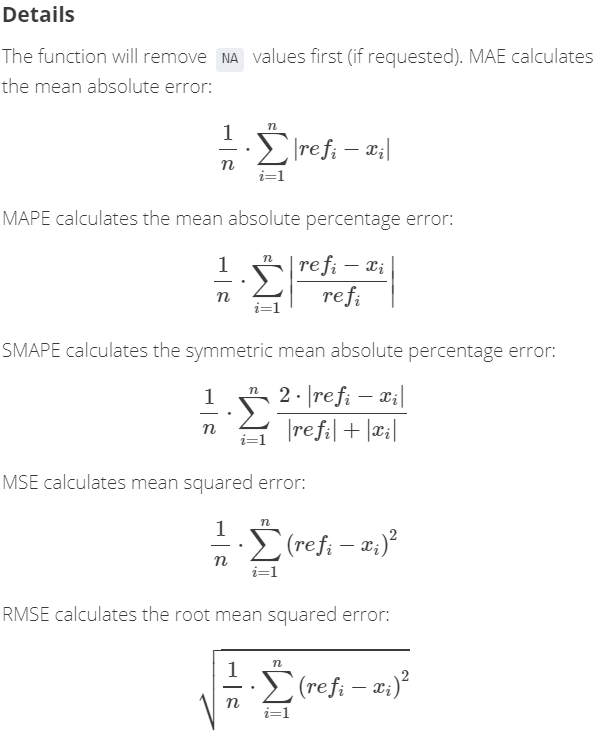

```r
options(scipen=10, digits=10)
Accuracy <- data.frame(Accuracy, stringsAsFactors=F)
Accuracy$mae <- as.numeric(Accuracy$mae)
Accuracy$mse <- as.numeric(Accuracy$mse)
Accuracy$rmse <- as.numeric(Accuracy$rmse)
Accuracy$mape <- as.numeric(Accuracy$mape)
row.names(Accuracy) <- NULL

Accuracy %>%
  select(Impute,mae,mse,rmse,mape) %>%
  kable(digits = 4, "html", caption = "Accuracy Results") %>%
    kable_styling(bootstrap_options = c("striped", "hover", "condensed", "responsive"), full_width = F, position = "left", font_size = 12)
```

Where $ref_i$ is observed true value and $x_i$ is predicted value. Ideally, difference these two values should be equal to `zero`. Since we are predicting, we cannot attain `zero`. It leaves us the only option, lower the better.

#### Using Mean

```r
BaseballDf_Mean <- BaseballDf_o %>% select(everything())

for(i in 1:ncol(BaseballDf_Mean)){
  BaseballDf_Mean[is.na(BaseballDf_Mean[,i]), i] <- mean(BaseballDf_Mean[,i], na.rm = TRUE)
}

lm.mb <- lm(TARGET_WINS ~ TEAM_BATTING_2B + TEAM_BATTING_3B + TEAM_BATTING_HR + TEAM_BATTING_BB + TEAM_BATTING_SO + TEAM_BASERUN_SB +  TEAM_PITCHING_SO + TEAM_FIELDING_E + TEAM_FIELDING_DP + TEAM_BATTING_1B, data = BaseballDf_Mean)

summary(lm.mb)
```

```
##
## Call:
## lm(formula = TARGET_WINS ~ TEAM_BATTING_2B + TEAM_BATTING_3B +
##     TEAM_BATTING_HR + TEAM_BATTING_BB + TEAM_BATTING_SO + TEAM_BASERUN_SB +
##     TEAM_PITCHING_SO + TEAM_FIELDING_E + TEAM_FIELDING_DP + TEAM_BATTING_1B,
##     data = BaseballDf_Mean)
##
## Residuals:
##        Min         1Q     Median         3Q        Max
## -51.827893  -8.557512   0.022449   8.395797  60.126816
##
## Coefficients:
##                       Estimate    Std. Error   t value
## (Intercept)      24.1867159343  5.2206593786   4.63289
## TEAM_BATTING_2B   0.0263340624  0.0072651689   3.62470
## TEAM_BATTING_3B   0.1165370007  0.0154459776   7.54481
## TEAM_BATTING_HR   0.1154108778  0.0086979850  13.26869
## TEAM_BATTING_BB   0.0108689776  0.0033511166   3.24339
## TEAM_BATTING_SO  -0.0081244038  0.0023975297  -3.38866
## TEAM_BASERUN_SB   0.0299345106  0.0042594387   7.02781
## TEAM_PITCHING_SO  0.0022186087  0.0005952681   3.72707
## TEAM_FIELDING_E  -0.0233891179  0.0020362604 -11.48631
## TEAM_FIELDING_DP -0.1210417959  0.0130186138  -9.29759
## TEAM_BATTING_1B   0.0473146166  0.0036264187  13.04720
##                              Pr(>|t|)
## (Intercept)      0.000003810562056120 ***
## TEAM_BATTING_2B            0.00029567 ***
## TEAM_BATTING_3B  0.000000000000065187 ***
## TEAM_BATTING_HR            < 2.22e-16 ***
## TEAM_BATTING_BB            0.00119834 **
## TEAM_BATTING_SO            0.00071438 ***
## TEAM_BASERUN_SB  0.000000000002765159 ***
## TEAM_PITCHING_SO           0.00019846 ***
## TEAM_FIELDING_E            < 2.22e-16 ***
## TEAM_FIELDING_DP           < 2.22e-16 ***
## TEAM_BATTING_1B            < 2.22e-16 ***
## ---
## Signif. codes:  0 '***' 0.001 '**' 0.01 '*' 0.05 '.' 0.1 ' ' 1
##
## Residual standard error: 13.04464 on 2265 degrees of freedom
## Multiple R-squared:  0.3172347,  Adjusted R-squared:  0.3142203
## F-statistic: 105.2392 on 10 and 2265 DF,  p-value: < 2.2204e-16
```

```r
BaseballDf_Median <- BaseballDf_o %>% select(everything())

for(i in 1:ncol(BaseballDf_Median)){
  BaseballDf_Median[is.na(BaseballDf_Median[,i]), i] <- mean(BaseballDf_Median[,i], na.rm = TRUE)
}

lm.mb <- lm(TARGET_WINS ~ TEAM_BATTING_2B + TEAM_BATTING_3B + TEAM_BATTING_HR + TEAM_BATTING_BB + TEAM_BATTING_SO + TEAM_BASERUN_SB + TEAM_PITCHING_SO + TEAM_FIELDING_E + TEAM_FIELDING_DP + TEAM_BATTING_1B, data = BaseballDf_Median)

summary(lm.mb)
```

```
##
## Call:
## lm(formula = TARGET_WINS ~ TEAM_BATTING_2B + TEAM_BATTING_3B +
##     TEAM_BATTING_HR + TEAM_BATTING_BB + TEAM_BATTING_SO + TEAM_BASERUN_SB +
##     TEAM_PITCHING_SO + TEAM_FIELDING_E + TEAM_FIELDING_DP + TEAM_BATTING_1B,
##     data = BaseballDf_Median)
##
## Residuals:
##        Min         1Q     Median         3Q        Max
## -51.827893  -8.557512   0.022449   8.395797  60.126816
##
## Coefficients:
##                       Estimate    Std. Error   t value
## (Intercept)      24.1867159343  5.2206593786   4.63289
## TEAM_BATTING_2B   0.0263340624  0.0072651689   3.62470
## TEAM_BATTING_3B   0.1165370007  0.0154459776   7.54481
## TEAM_BATTING_HR   0.1154108778  0.0086979850  13.26869
## TEAM_BATTING_BB   0.0108689776  0.0033511166   3.24339
## TEAM_BATTING_SO  -0.0081244038  0.0023975297  -3.38866
## TEAM_BASERUN_SB   0.0299345106  0.0042594387   7.02781
## TEAM_PITCHING_SO  0.0022186087  0.0005952681   3.72707
## TEAM_FIELDING_E  -0.0233891179  0.0020362604 -11.48631
## TEAM_FIELDING_DP -0.1210417959  0.0130186138  -9.29759
## TEAM_BATTING_1B   0.0473146166  0.0036264187  13.04720
##                              Pr(>|t|)
## (Intercept)      0.000003810562056120 ***
## TEAM_BATTING_2B            0.00029567 ***
## TEAM_BATTING_3B  0.000000000000065187 ***
## TEAM_BATTING_HR            < 2.22e-16 ***
## TEAM_BATTING_BB            0.00119834 **
## TEAM_BATTING_SO            0.00071438 ***
## TEAM_BASERUN_SB  0.000000000002765159 ***
## TEAM_PITCHING_SO           0.00019846 ***
## TEAM_FIELDING_E            < 2.22e-16 ***
## TEAM_FIELDING_DP           < 2.22e-16 ***
## TEAM_BATTING_1B            < 2.22e-16 ***
## ---
## Signif. codes:  0 '***' 0.001 '**' 0.01 '*' 0.05 '.' 0.1 ' ' 1
##
## Residual standard error: 13.04464 on 2265 degrees of freedom
## Multiple R-squared:  0.3172347,  Adjusted R-squared:  0.3142203
## F-statistic: 105.2392 on 10 and 2265 DF,  p-value: < 2.2204e-16
```

#### Using Mode

```r
BaseballDf_Mode <- BaseballDf_o %>% select(everything())

for(i in 1:ncol(BaseballDf_Mode)){
  BaseballDf_Mode[is.na(BaseballDf_Mode[,i]), i] <- getmode(BaseballDf_Mode[,i])
}

lm.mb <- lm(TARGET_WINS ~ TEAM_BATTING_2B + TEAM_BATTING_3B + TEAM_BATTING_HR + TEAM_BATTING_BB + TEAM_BATTING_SO + TEAM_BASERUN_SB + TEAM_PITCHING_SO + TEAM_FIELDING_E + TEAM_FIELDING_DP + TEAM_BATTING_1B, data = BaseballDf_Mode)

summary(lm.mb)
```

```
##
## Call:
## lm(formula = TARGET_WINS ~ TEAM_BATTING_2B + TEAM_BATTING_3B +
##     TEAM_BATTING_HR + TEAM_BATTING_BB + TEAM_BATTING_SO + TEAM_BASERUN_SB +
##     TEAM_PITCHING_SO + TEAM_FIELDING_E + TEAM_FIELDING_DP + TEAM_BATTING_1B,
##     data = BaseballDf_Mode)
##
## Residuals:
##        Min         1Q     Median         3Q        Max
## -53.689418  -8.520449   0.055422   8.343419  60.739162
##
## Coefficients:
##                       Estimate    Std. Error  t value       Pr(>|t|)
## (Intercept)      20.6798513694  3.9902129237  5.18264 0.000000238127 ***
## TEAM_BATTING_2B   0.0273631126  0.0073533137  3.72119     0.00020311 ***
## TEAM_BATTING_3B   0.1280221328  0.0152439526  8.39822     < 2.22e-16 ***
## TEAM_BATTING_HR   0.1162550387  0.0086311027 13.46931     < 2.22e-16 ***
## TEAM_BATTING_BB   0.0127373857  0.0033725382  3.77680     0.00016295 ***
## TEAM_BATTING_SO  -0.0078459204  0.0018397997 -4.26455 0.000020852771 ***
## TEAM_BASERUN_SB   0.0214599487  0.0039140928  5.48274 0.000000046533 ***
## TEAM_PITCHING_SO  0.0022879415  0.0005982148  3.82462     0.00013452 ***
## TEAM_FIELDING_E  -0.0198593592  0.0019867022 -9.99614     < 2.22e-16 ***
## TEAM_FIELDING_DP -0.1094313337  0.0126639235 -8.64119     < 2.22e-16 ***
## TEAM_BATTING_1B   0.0471796866  0.0033904005 13.91567     < 2.22e-16 ***
## ---
## Signif. codes:  0 '***' 0.001 '**' 0.01 '*' 0.05 '.' 0.1 ' ' 1
##
## Residual standard error: 13.10699 on 2265 degrees of freedom
## Multiple R-squared:  0.310693,   Adjusted R-squared:  0.3076497
## F-statistic: 102.0909 on 10 and 2265 DF,  p-value: < 2.2204e-16
```

#### Using kNN

```r
BaseballDf_kNN <- BaseballDf_o %>% select(everything())

BaseballDf_kNN <- knnImputation(BaseballDf_kNN, 15, meth='weighAvg')

for(i in 1:ncol(BaseballDf_kNN)){
  BaseballDf_kNN[is.na(BaseballDf_kNN[,i]), i] <- as.numeric(as.character(BaseballDf_kNN[is.na(BaseballDf_kNN[,i]), i]))
}

BaseballDf_NA$TEAM_BATTING_SO <- as.numeric(as.character(BaseballDf_NA$TEAM_BATTING_SO))

lm.mb <- lm(TARGET_WINS ~ TEAM_BATTING_2B + TEAM_BATTING_3B + TEAM_BATTING_HR + TEAM_BATTING_BB + TEAM_BATTING_SO + TEAM_BASERUN_SB + TEAM_PITCHING_SO + TEAM_FIELDING_E + TEAM_FIELDING_DP + TEAM_BATTING_1B, data = BaseballDf_kNN)

summary(lm.mb)
```

```
##
## Call:
## lm(formula = TARGET_WINS ~ TEAM_BATTING_2B + TEAM_BATTING_3B +
##     TEAM_BATTING_HR + TEAM_BATTING_BB + TEAM_BATTING_SO + TEAM_BASERUN_SB +
##     TEAM_PITCHING_SO + TEAM_FIELDING_E + TEAM_FIELDING_DP + TEAM_BATTING_1B,
##     data = BaseballDf_kNN)
##
## Residuals:
##        Min         1Q     Median         3Q        Max
## -51.271737  -8.365329   0.087365   8.203016  65.306607
##
## Coefficients:
##                       Estimate    Std. Error   t value         Pr(>|t|)
## (Intercept)      32.4992489506  5.1031333130   6.36849 0.00000000023043
## TEAM_BATTING_2B   0.0296532395  0.0071886220   4.12502 0.00003840791221
## TEAM_BATTING_3B   0.0944955023  0.0153091312   6.17249 0.00000000079415
## TEAM_BATTING_HR   0.1250252998  0.0086947790  14.37935       < 2.22e-16
## TEAM_BATTING_BB   0.0082089498  0.0032458991   2.52902         0.011505
## TEAM_BATTING_SO  -0.0135337105  0.0024245555  -5.58193 0.00000002662933
## TEAM_BASERUN_SB   0.0379514117  0.0044104955   8.60480       < 2.22e-16
## TEAM_PITCHING_SO  0.0026126376  0.0005895419   4.43164 0.00000979769717
## TEAM_FIELDING_E  -0.0296694570  0.0020466397 -14.49667       < 2.22e-16
## TEAM_FIELDING_DP -0.1270232083  0.0136841948  -9.28248       < 2.22e-16
## TEAM_BATTING_1B   0.0445134431  0.0036012791  12.36045       < 2.22e-16
##
## (Intercept)      ***
## TEAM_BATTING_2B  ***
## TEAM_BATTING_3B  ***
## TEAM_BATTING_HR  ***
## TEAM_BATTING_BB  *
## TEAM_BATTING_SO  ***
## TEAM_BASERUN_SB  ***
## TEAM_PITCHING_SO ***
## TEAM_FIELDING_E  ***
## TEAM_FIELDING_DP ***
## TEAM_BATTING_1B  ***
## ---
## Signif. codes:  0 '***' 0.001 '**' 0.01 '*' 0.05 '.' 0.1 ' ' 1
##
## Residual standard error: 12.88364 on 2265 degrees of freedom
## Multiple R-squared:  0.3339851,  Adjusted R-squared:  0.3310446
## F-statistic: 113.5825 on 10 and 2265 DF,  p-value: < 2.2204e-16
```

$R^2$ value for `kNN` imputed dataset is better than other three models. It opens up many other options. We can use `SVN`, `Random Forest`, `Maximum Entropy` methods. Also, we can use `confusion matrix` to fine tune the method before applying to the dataset.

#### References

- https://www.tutorialspoint.com/r/r_mean_median_mode.htm
- https://www.rdocumentation.org/packages/DescTools/versions/0.99.19/topics/Measures%20of%20Accuracy
- https://www.analyticsvidhya.com/blog/2016/03/tutorial-powerful-packages-imputing-missing-values/
- https://datascienceplus.com/missing-value-treatment/